# ProEdge

We start by building a click prediction engine using scikit learn. The aim of this notebook is to show how a machine learning model can be built end to end.

Brief Introduction: Direct marketing, either through mail, email, phone, etc., is a common tactic to acquire customers. Because resources and a customer's attention is limited, the goal is to only target the subset of prospects who are likely to engage with a specific offer. Predicting those potential customers based on readily available information like demographics, past interactions, and environmental factors is a common machine learning problem.

PROBLEM STATEMENT: To predict if a customer will click on an Ad or not after pushing out campaigns.

```python
import pandas as pd #Remember the pandas library we spoke about. It helps to read and write data into/from a file
```

```python
df = pd.read_csv("new_click_data.csv")
```

```python
df.head() #calling .head() on a dataframe helps you visualise what the data looks like. In this case, the default is to display the top 5 rows in the dataset. You could have .head(10) which gives you the top 10 rows in the file.
```

|  | age | location_region | os_name | customer_class | customer_value | spend_total | y |
| --- | --- | --- | --- | --- | --- | --- | --- |
| 0 | 42.0 | South West | android | 44.0 | 5.0 | 15670.380000 | 0 |
| 1 | 20.0 | South West | ios | 44.0 | 4.0 | 6741.240000 | 0 |
| 2 | 28.0 | South South | android | 46.0 | 3.0 | 3811.180000 | 0 |
| 3 | 44.0 | South West | proprietary os | 184.0 | 3.0 | 3592.284065 | 0 |
| 4 | 26.0 | South South | android | 44.0 | 4.0 | 10139.103000 | 0 |

```python
df['y'].value_counts() #value counts helps count the frequency of unique attributes specified
```

```
0    1058329
1       5706
Name: y, dtype: int64
```

```python
df.shape #this tells you the number of rows and columns that you have
```

```
(1064035, 7)
```

```python
df.info() #gives brief description of the data you have. The data type, if there are null objects, no of rows
```

```
<class 'pandas.core.frame.DataFrame'>
RangeIndex: 1064035 entries, 0 to 1064034
Data columns (total 7 columns):
age                1064035 non-null float64
location_region    1064035 non-null object
os_name            1064035 non-null object
customer_class     1064035 non-null float64
customer_value     1064035 non-null float64
spend_total        1064035 non-null float64
y                  1064035 non-null int64
dtypes: float64(4), int64(1), object(2)
memory usage: 56.8+ MB
```

Explanation of each attribute

- Age : that's the age of the user
- location_region: the region where the user resides
- os_name: the type of operating system the user is using which gives information about the type of phone
- customer_class: a grouping on the type of customer, whether he/she is a high net individual or not. The higher the number, the higher the class
- customer_value: the value of the customer, whether he/she is a top/very high/high/medium/low customer
- spend_total: the spend of the user on airtime, data, and value added services
- y: the indicator of whether or not the user clicked on the campaign advertisement

Refer to pre-processing file below for the data up. This process has been taken care of, data shared with you is in its clean state.

```python
list_region = ["South West", "South East", "South South", "North Central", "North West", "North East"]
list_os_name = ["android", "proprietary os", "symbian os", "ios", "series30", "series40", "samsung os", "blackberry os", "mtk rtos", "windows phone", "nucleus", "series 60", "lg os", "nokia os", "asha software", "windows mobile", "siemens os", "spreadtrum os", "belle", "yun os", "isa", "mocor os", "tizen", "panasonic os", "motomagx", "bada"]

def pre_process(data):
    features = ["age", "location_region", "os_name", "customer_class", "customer_value", "spend_total"]
    data = data[features]
    data.age = abs(data.age)
    data['age'] = data['age'].apply(lambda x : 60.0 if x > 60.0 else x)
    data['age'].fillna((data['age'].mean()), inplace=True)

    data['location_region']= data['location_region'].apply(lambda x : x if x in list_region else "South West")

    data['os_name'] = data['os_name'].apply(lambda x : x if x in list_os_name else "android")

    data['customer_class'] = data['customer_class'].fillna((data['customer_class'].mean()), inplace=True)

    data['customer_value'] = data.customer_value.map({'top':5, 'very high':4, 'high':3, 'medium':2, 'low':1})

    data['customer_value'] = data['customer_value'].fillna((data['customer_value'].mean()), inplace=True)

    data['spend_total'] = data['spend_total'].fillna((data['spend_total'].mean()), inplace=True)

    return data
```

```python
model_data = pd.get_dummies(df) #The pd.get_dummies functionality converts the categorical variables to numeric variables. Typically, models used for ML only understand numeric variables.
```

Modeling

We'd import the libraries to be used for modeling.

```python
## model selection
from sklearn.model_selection import StratifiedShuffleSplit, cross_val_score

## smote
from imblearn.over_sampling import SMOTE

## classifiers
from sklearn.tree import DecisionTreeClassifier
from sklearn.svm import SVC
from sklearn.neighbors import KNeighborsClassifier
from sklearn.linear_model import LogisticRegression, SGDClassifier
from yellowbrick.classifier import ConfusionMatrix, ClassificationReport

## metrics
from sklearn.metrics import precision_recall_curve, make_scorer, confusion_matrix, classification_report

import itertools
```

Let's start by splitting the data into train and test dataset

```python
split = StratifiedShuffleSplit(n_splits=1, test_size=0.2, random_state=42)
for train_index, test_index in split.split(model_data, model_data['y']):
    strat_train_set = model_data.loc[train_index]
    strat_test_set = model_data.loc[test_index]
```

Note; the random state value can be anything. The random_state parameter is used for reproducibility of the initial shuffling of training datasets after each epoch (one of the hyperparameters). Other hyperparameters are learning rates and batch sizes.

```python
strat_train_set.shape, strat_test_set.shape #Note that this conforms to the split we did above with the test size at 20%.
```

```
((851228, 36), (212807, 36))
```

```python
strat_train_set.dropna(axis=0, inplace=True)
strat_test_set.dropna(axis=0, inplace=True) #This is done to ensure that there are no NaN (not a number) values in a dataset. If NaN values are present, training cannot be done
```

While training your dataset, think of dependent and independent variables. For this particular use case, the 'y' is the target variable while the 'X' are the set of attributes that would be trained to get the accurate value of Y

```python
X_train = strat_train_set.drop(['y'],axis=1)
y_train = strat_train_set.y
X_test = strat_test_set.drop(['y'],axis=1)
y_test = strat_test_set.y
```

Now that we have separated into train and test, we need to ensure that uneven distribution of the 'Y' variable is taken care of

```python
smote_algo = SMOTE(random_state=0)
smote_data_X,smote_data_Y = smote_algo.fit_sample(X_train, y_train)
smote_data_X = pd.DataFrame(data=smote_data_X,columns=X_train.columns)
smote_data_Y= pd.DataFrame(data=smote_data_Y,columns=["y"])
```

```python
X_train  = smote_data_X
y_train  = smote_data_Y #It's always advisable to label your X and Y appropriately so you can easily identify the data used for training
```

```python
log_reg = LogisticRegression(class_weight='balanced') # class_weight balanced helps handle the imbalance further
```

```python
log_reg.fit(X_train, y_train) #this is where the magic happens
```

```
LogisticRegression(C=1.0, class_weight='balanced', dual=False,
          fit_intercept=True, intercept_scaling=1, max_iter=100,
          multi_class='ovr', n_jobs=1, penalty='l2', random_state=None,
          solver='liblinear', tol=0.0001, verbose=0, warm_start=False)
```

```python
log_reg.score(X_test, y_test) #this is the accuracy score of the model
```

```
0.8440229879656215
```

```python
log_reg.predict_proba(X_test)
```

```
array([[0.59697217, 0.40302783],
       [0.63974758, 0.36025242],
       [0.5552535 , 0.4447465 ],
       ...,
       [0.60725885, 0.39274115],
       [0.58607447, 0.41392553],
       [0.6041823 , 0.3958177 ]])
```

```python
def show_classification_report(model):
    visualizer = ClassificationReport(model, support=True)
    visualizer.fit(X_train, y_train)
    visualizer.score(X_test, y_test)
    return visualizer
```

```python
from yellowbrick.classifier import ClassPredictionError,ClassificationReport,ROCAUC,ClassBalance,DiscriminationThreshold,ConfusionMatrix
```

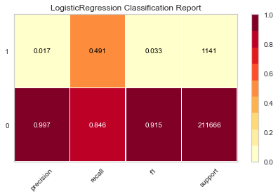

```python
show_classification_report(log_reg).poof()
```

Evaluation Explanation;

- Precision: it's the ability of the classifier not to label an instance positive that is actually negative. For all instance classified positive, what percentage was correct ?
- Recall: it's the ability of the classifier to find all positive instances. For all instances they were actually positive, what percentage was classified correctly?
- F1: it's the weighted harmonic mean of precision and recall such that the best score is 1.0 and the worst score is 0.0. As a rule of thumb, the weighted average of F1 should be used to compare classifier models not global accuracy.

Confusion matrix

```python
def show_confusion_matrix(model):
    cm = ConfusionMatrix(model)
    cm.fit(X_train, y_train)
    cm.score(X_test, y_test)
    return cm
```

```
ConfusionMatrix(ax=<matplotlib.axes._subplots.AxesSubplot object at 0x114b22a90>,
        classes=None,
        cmap=<matplotlib.colors.ListedColormap object at 0x114bd09e8>,
        fontsize=None, label_encoder=None, model=None, percent=False,
        sample_weight=None)
```

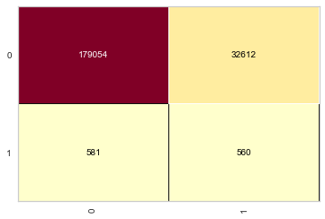

```python
show_confusion_matrix(log_reg)
```

```python
from sklearn.externals import joblib
joblib.dump(log_reg, 'general.pkl')
```

```
['general.pkl']
```

The general.pkl file is what applications use to make predictions. It's a place holder for the model. When you bring new datasets that are real life data, ensure that the preprocessing is done appropriately and the number of inputs conforms to that in the training and test dataset.